TIC-1

# LAB-02 : Amazon Virtual Private Cloud (VPC)

## Terminologie

[Suivant | Haut]

Dans cette section on va introduire quelques concepts clés liés au service VPC.

### Virtual private cloud (VPC)

C'est un réseau virtuel dédié à votre compte AWS. Vous le créez et vous pourrez ensuite y ajouter des ressources. Vous pouvez spécifier une plage d'adresses IP pour votre VPC, créer des sous-réseaux, configurer des tables de routage et des passerelles. Vous pouvez aussi appliquer plusieurs couches de sécurité, à savoir les groupes de sécurité et les listes de contrôles d'accès au réseau (NACL), ce qui renforce le contrôle d'accès aux ressources dans chaque sous-réseau. Un VPC couvre toutes les zones de disponibilité de la région.

### VPC par défaut

La première fois que vous lancer des ressources EC2, ces dernières sont créées dans un VPC par défaut (si aucun autre VPC personnalisé n'est pas précisé). En effet, chaque compte AWS est livré avec un VPC par défaut (172.31.0.0/16) qui a un sous-réseau public par défaut dans chaque zone de disponibilité. Il est connecté à une passerelle Internet et chaque instance lancée dans un sous-réseau par défaut possède une adresse IPv4 privée et une adresse IPv4 publique. Vous pouvez également créer votre propre VPC, appelé VPC personnalisé, et le configurer selon vos besoins.

### Sous-réseau (subnet)

Après avoir créé un VPC, vous pouvez ajouter un ou plusieurs sous-réseaux. Un sous-réseau est une plage d'adresses IP dans votre VPC. Chaque sous-réseau doit résider entièrement dans une zone de disponibilité et ne peut pas s'étendre sur plusieurs zones.

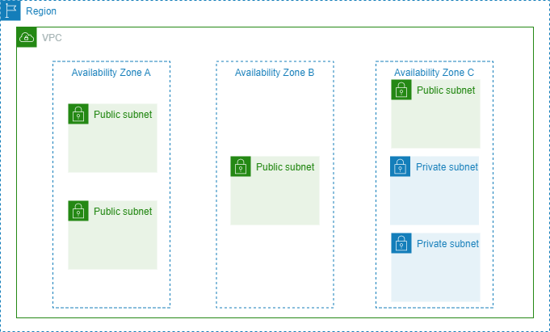

Utilisez un sous-réseau public pour les ressources qui doivent être connectées à Internet et un sous-réseau privé pour les ressources qui ne doivent pas être connectées.

### Table de routage (route table)

C'est l'ensemble de règles, appelées routes, qui permettent de déterminer où le trafic réseau est dirigé. Chaque sous-réseau de votre VPC doit être associé à une table de routage. Vous pouvez associer explicitement un sous-réseau à une table de routage personnalisée. Sinon, le sous-réseau est implicitement associé à la table de routage principale.

Un sous-réseau peut être associé à une seule table de routage à la fois, mais vous pouvez associer plusieurs sous-réseaux à une même table de routage.

### Table de routage principale (main route table)

Il s'agit de la table de routage qui est associée automatiquement à votre VPC. Elle contrôle le routage pour tous les sous-réseaux qui ne sont associés explicitement à aucune autre table de routage. Par défaut, lorsque vous créez un VPC personnalisé, la table de routage principale contient seulement une route par défaut pour le routage local dans le VPC; elle permet aux instances dans le VPC de communiquer entre elles.

Vous pouvez créer des tables de routage personnalisées pour votre VPC.

### Passerelle Internet (Internet Gateways)

C'est la passerelle que vous attachez à votre VPC pour permettre la communication entre les ressources de votre VPC et l'internet. Elle est redondante et hautement disponible. Si un sous-réseau est associé à une table de routage comportant une route vers une passerelle Internet, il est considéré comme un sous-réseau public.

### Passerelle NAT (NAT Gateways)

C'est un service de traduction d'adresses réseau (Network Address Translation). Elle est utilisée de façon à ce que les instances d'un sous-réseau privé puissent se connecter à des services en dehors de VPC, mais que des services externes ne puissent pas initier une connexion avec ces instances.

## Scénario d'un VPC avec deux sous-réseaux : public et privé

[Précédent | Suivant | Haut]

L'architecture de ce scénario comprend un VPC avec un sous-réseau public et un sous-réseau privé. Ce scénario est conseillé si vous voulez exécuter une application Web multi-tiers où vous allez placer :

- les serveurs Web destinés au public dans un sous-réseau public
- les serveurs de base de données qui ne doivent pas être accessibles par tout le monde dans un sous-réseau privé.

[figure not shown]

Les serveurs du sous-réseau public peuvent envoyer le trafic sortant directement sur le réseau Internet à travers une passerelle Internet, tandis que les serveurs du sous-réseau privé ne le peuvent pas. Ces derniers peuvent accéder à Internet (pour les mises à jour logicielles par exemple) à l'aide d'une passerelle de traduction d'adresses réseau (NAT) qui se trouve dans le sous-réseau public.

Vous pouvez définir la sécurité et le routage de sorte que les serveurs Web puissent communiquer avec les serveurs de base de données.

**Création du VPC et de deux sous-réseaux :**

Ouvrez la console du service Amazon VPC et cliquez sur "Create VPC". Sélectionnez "VPC and more" et définissez le valeurs suivantes :

- IPv4 CIDR block : 10.0.0.0/16
- Number of Availability Zones (AZs) : 1
- Number of public subnets : 1
- Number of private subnets : 1
- NAT gateways : 1
- VPC endpoints : None

Vérifiez la création de votre VPC et vos deux sous réseaux.

## Création des instances et connexion SSH

[Précédent | Haut]

Dans cette section vous allez créer deux instances EC2 : une dans le sous-réseau public et l'autre dans le sous-réseau privé. Par la suite vous allez essayer d'établir une connexion SSH avec ces deux instances.

Ouvrez la console du service EC2 et lancez la création de votre première instance. Sous "Network settings", sélectionnez votre VPC et votre sous-réseau public et activez l'attribution automatique d'adresse IP publique.

Etablissez une connexion SSH à votre première instance située dans le sous-réseau public.

*Est-ce que vous avez pu vous connecter à votre instance ?* Expliquez

Procédez maintenant à la création de votre deuxième instance. Sous "Network settings", sélectionnez votre VPC et votre sous-réseau privé. Vous n'avez pas besoin d'activer l'attribution automatique d'adresse IP publique car l'instance est dans un sous-réseau privé.

Etablissez une connexion SSH à votre deuxième instance située dans le sous-réseau privé.

*Est-ce que vous avez pu vous connecter à votre instance ?* Expliquez

Tek-up 2022/2023